# RLS modelling results

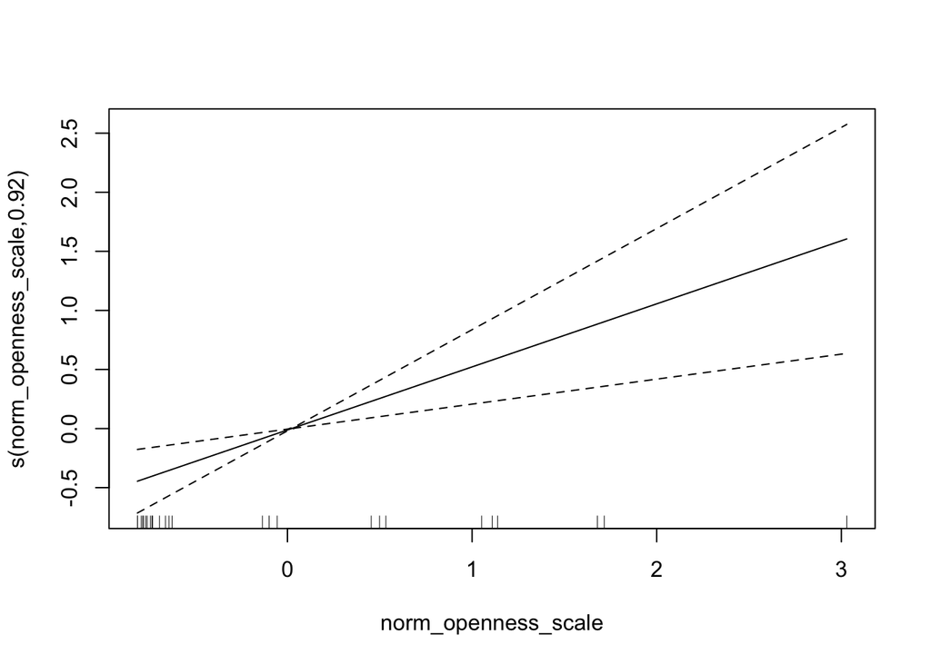

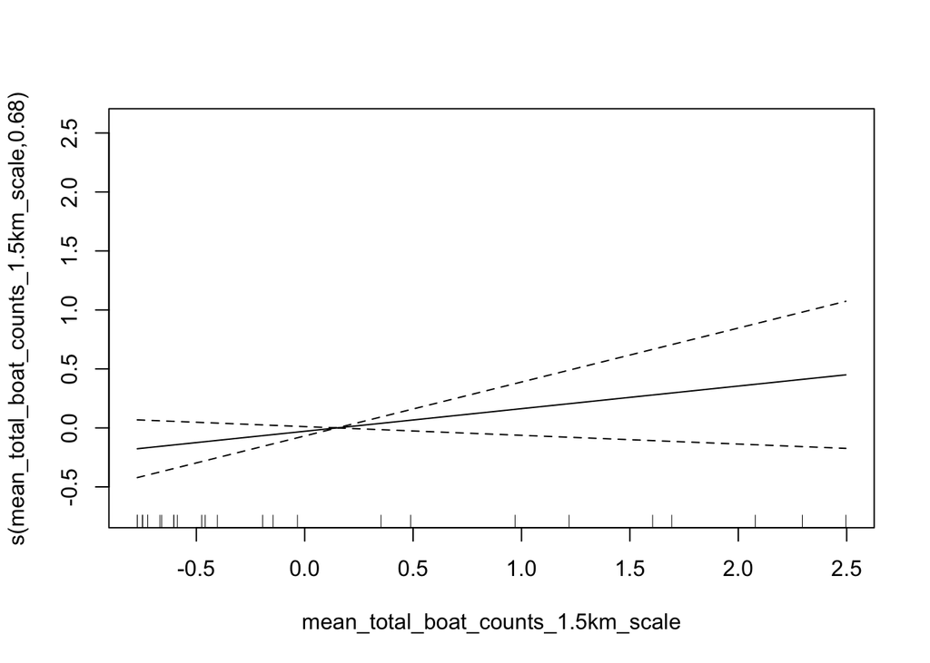

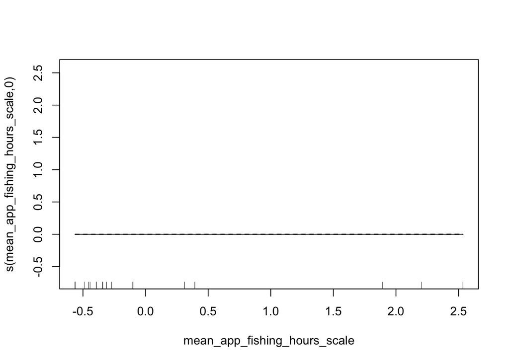

```
##
## Family: gaussian
## Link function: identity
##
## Formula:
## urch_sn_ratio_avg ~ s(sst_scale) + s(norm_openness_scale) + s(mean_total_boat_counts_1.5km_scale) +
##     s(mean_app_fishing_hours_scale)
##
## Parametric coefficients:
##             Estimate Std. Error t value Pr(>|t|)
## (Intercept)   0.7994     0.1703   4.693 9.59e-05 ***
## ---
## Signif. codes:  0 '***' 0.001 '**' 0.01 '*' 0.05 '.' 0.1 ' ' 1
##
## Approximate significance of smooth terms:
##                                             edf Ref.df     F p-value
## s(sst_scale)                          4.868e-04      9 0.000 0.36467
## s(norm_openness_scale)                9.165e-01      9 1.220 0.00208 **
## s(mean_total_boat_counts_1.5km_scale) 6.757e-01      9 0.232 0.09215 .
## s(mean_app_fishing_hours_scale)       1.252e-05      9 0.000 0.52560
## ---
## Signif. codes:  0 '***' 0.001 '**' 0.01 '*' 0.05 '.' 0.1 ' ' 1
##
## R-sq.(adj) =  0.364   Deviance explained = 40.5%
## -REML = 35.388  Scale est. = 0.75426   n = 26
```

##### Testing the residuals for autocorrelation

```
##
##  Moran I test under randomisation
##
## data:  residuals_total_mod_1.5km_total_boats_avg
## weights: lw_avg
## n reduced by no-neighbour observations
##
## Moran I statistic standard deviate = 0.4127, p-value = 0.3399
## alternative hypothesis: greater
## sample estimates:
## Moran I statistic       Expectation          Variance
##        0.01870135       -0.11111111        0.09893814
```

```
##
##  Moran I test under randomisation
##
## data:  residuals_total_mod_1.5km_total_boats_avg
## weights: lw_inverse_avg
##
## Moran I statistic standard deviate = 0.74985, p-value = 0.2267
## alternative hypothesis: greater
## sample estimates:
## Moran I statistic       Expectation          Variance
##       0.014497979      -0.040000000       0.005282192
```

No spatial autocorrelation.

##### Testing the model for concurvity

```
## $worst
##                                               para s(sst_scale)
## para                                  1.000000e+00 2.111799e-24
## s(sst_scale)                          2.106192e-24 1.000000e+00
## s(norm_openness_scale)                2.630097e-23 9.517659e-01
## s(mean_total_boat_counts_1.5km_scale) 2.065509e-21 8.171219e-01
## s(mean_app_fishing_hours_scale)       1.429373e-18 9.996369e-01
##                                       s(norm_openness_scale)
## para                                            2.633319e-23
## s(sst_scale)                                    9.517659e-01
## s(norm_openness_scale)                          1.000000e+00
## s(mean_total_boat_counts_1.5km_scale)           8.758240e-01
## s(mean_app_fishing_hours_scale)                 9.129862e-01
##                                       s(mean_total_boat_counts_1.5km_scale)
## para                                                           2.065622e-21
## s(sst_scale)                                                   8.171219e-01
## s(norm_openness_scale)                                         8.758240e-01
## s(mean_total_boat_counts_1.5km_scale)                          1.000000e+00
## s(mean_app_fishing_hours_scale)                                9.997509e-01
##                                       s(mean_app_fishing_hours_scale)
## para                                                     1.429339e-18
## s(sst_scale)                                             9.996369e-01
## s(norm_openness_scale)                                   9.129862e-01
## s(mean_total_boat_counts_1.5km_scale)                    9.997509e-01
## s(mean_app_fishing_hours_scale)                          1.000000e+00
##
## $observed
##                                               para s(sst_scale)
## para                                  1.000000e+00 3.152381e-30
## s(sst_scale)                          2.106192e-24 1.000000e+00
## s(norm_openness_scale)                2.630097e-23 5.270019e-01
## s(mean_total_boat_counts_1.5km_scale) 2.065509e-21 3.950673e-01
## s(mean_app_fishing_hours_scale)       1.429373e-18 4.779810e-01
##                                       s(norm_openness_scale)
## para                                            1.894850e-33
## s(sst_scale)                                    4.948961e-01
## s(norm_openness_scale)                          1.000000e+00
## s(mean_total_boat_counts_1.5km_scale)           6.330602e-01
## s(mean_app_fishing_hours_scale)                 2.048901e-01
##                                       s(mean_total_boat_counts_1.5km_scale)
```

[output cut: 22 more lines]

```
## s(norm_openness_scale)                          1.000000e+00
## s(mean_total_boat_counts_1.5km_scale)           5.487616e-01
## s(mean_app_fishing_hours_scale)                 2.003710e-01
##                                       s(mean_total_boat_counts_1.5km_scale)
## para                                                           9.858033e-25
## s(sst_scale)                                                   4.753316e-01
## s(norm_openness_scale)                                         5.115010e-01
## s(mean_total_boat_counts_1.5km_scale)                          1.000000e+00
## s(mean_app_fishing_hours_scale)                                5.658184e-01
##                                       s(mean_app_fishing_hours_scale)
## para                                                     1.313946e-22
## s(sst_scale)                                             3.517142e-01
## s(norm_openness_scale)                                   3.150262e-01
## s(mean_total_boat_counts_1.5km_scale)                    6.078557e-01
## s(mean_app_fishing_hours_scale)                          1.000000e+00
```

Some of the variables appear to have high concurvity scores in the worst case, but confidence intervals seem stable for the model plots. May need to get rid of the mean apparent fishing hours however. Since the concurvity was very high.

#### Model with 2 km total boats avg

```r
total_mod_2km_total_boats_avg <- gam(urch_sn_ratio_avg ~ s(sst_scale) +
                   s(norm_openness_scale) +
                   s(mean_total_boat_counts_2km_scale)+
                   s(mean_app_fishing_hours_scale),
               data = env_mod_data_avg,
               family = gaussian(link = "identity"),
               method = 'REML',
               select = TRUE)
```

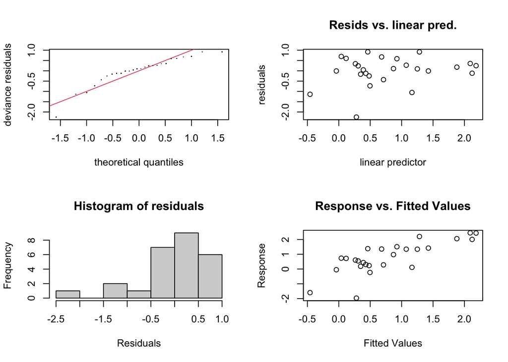

```
##
## Method: REML   Optimizer: outer newton
## full convergence after 17 iterations.
## Gradient range [-6.295319e-05,0.0001468631]
## (score 34.67869 & scale 0.5848169).
## Hessian positive definite, eigenvalue range [1.797214e-06,12.59484].
## Model rank =  37 / 37
##
## Basis dimension (k) checking results. Low p-value (k-index<1) may
## indicate that k is too low, especially if edf is close to k'.
##
##                                        k'   edf k-index p-value
## s(sst_scale)                        9.000 1.470    1.07    0.55
## s(norm_openness_scale)              9.000 0.883    1.12    0.66
## s(mean_total_boat_counts_2km_scale) 9.000 1.467    1.29    0.93
## s(mean_app_fishing_hours_scale)     9.000 0.466    1.16    0.73
```

```
##                           (Intercept)                        s(sst_scale).1
##                          7.993946e-01                          7.254454e-02
##                        s(sst_scale).2                        s(sst_scale).3
##                         -1.697636e-01                         -4.469557e-02
##                        s(sst_scale).4                        s(sst_scale).5
##                         -1.545938e-01                          1.474529e-01
##                        s(sst_scale).6                        s(sst_scale).7
##                          1.403613e-01                          1.304006e-01
##                        s(sst_scale).8                        s(sst_scale).9
##                         -8.571878e-01                          5.941259e-08
##              s(norm_openness_scale).1              s(norm_openness_scale).2
##                         -3.221450e-07                          1.288896e-07
##              s(norm_openness_scale).3              s(norm_openness_scale).4
##                          6.405998e-08                         -7.471358e-08
##              s(norm_openness_scale).5              s(norm_openness_scale).6
##                          1.881601e-09                         -9.927996e-09
##              s(norm_openness_scale).7              s(norm_openness_scale).8
##                          1.633079e-08                          2.223967e-07
##              s(norm_openness_scale).9 s(mean_total_boat_counts_2km_scale).1
##                          4.362565e-01                          2.757286e-01
## s(mean_total_boat_counts_2km_scale).2 s(mean_total_boat_counts_2km_scale).3
##                          2.121303e-01                          1.204279e-01
## s(mean_total_boat_counts_2km_scale).4 s(mean_total_boat_counts_2km_scale).5
##                          1.598844e-01                          3.744327e-02
## s(mean_total_boat_counts_2km_scale).6 s(mean_total_boat_counts_2km_scale).7
##                          1.357331e-01                         -1.309919e-01
## s(mean_total_boat_counts_2km_scale).8 s(mean_total_boat_counts_2km_scale).9
##                          7.244462e-01                          1.141403e-01
##     s(mean_app_fishing_hours_scale).1     s(mean_app_fishing_hours_scale).2
##                         -6.152899e-05                          5.072881e-06
##     s(mean_app_fishing_hours_scale).3     s(mean_app_fishing_hours_scale).4
##                         -2.762876e-05                         -1.571223e-05
##     s(mean_app_fishing_hours_scale).5     s(mean_app_fishing_hours_scale).6
##                          1.908859e-05                          2.249670e-05
##     s(mean_app_fishing_hours_scale).7     s(mean_app_fishing_hours_scale).8
##                          2.169736e-05                         -1.209237e-04
##     s(mean_app_fishing_hours_scale).9
##                         -1.106960e-01
```

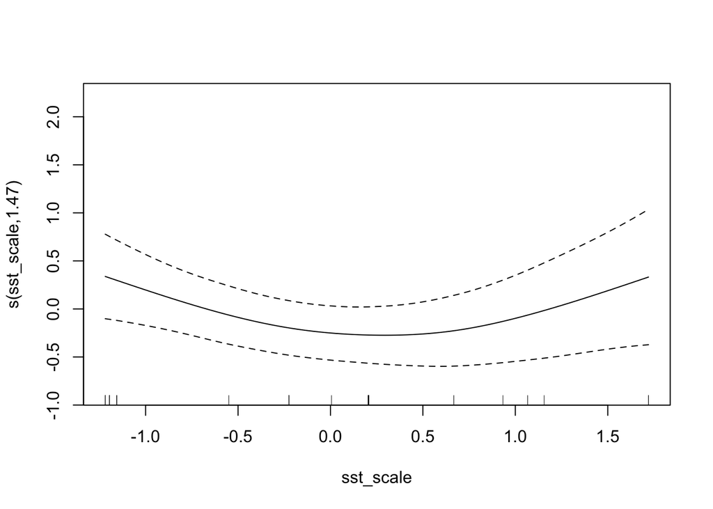

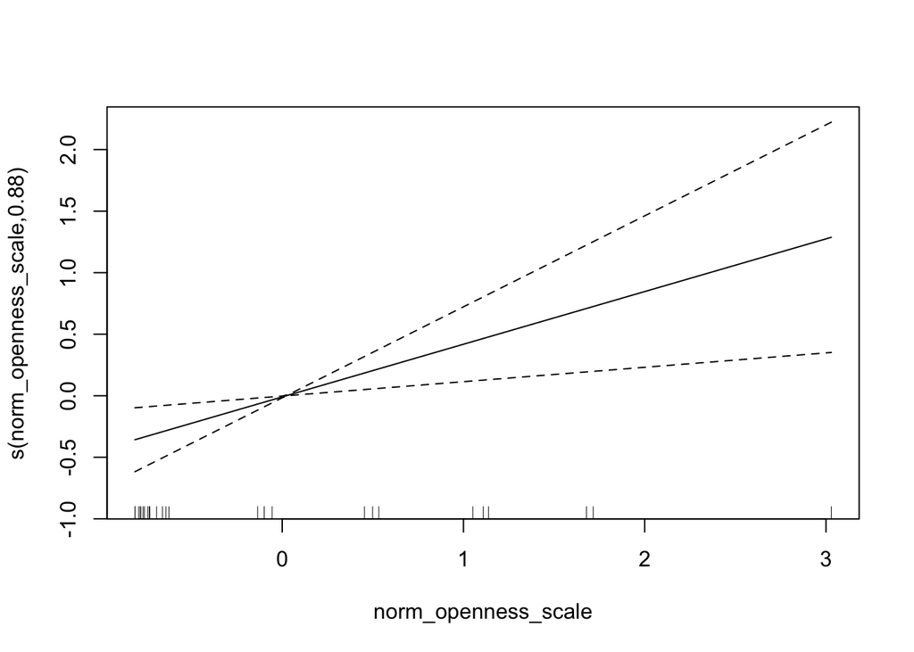

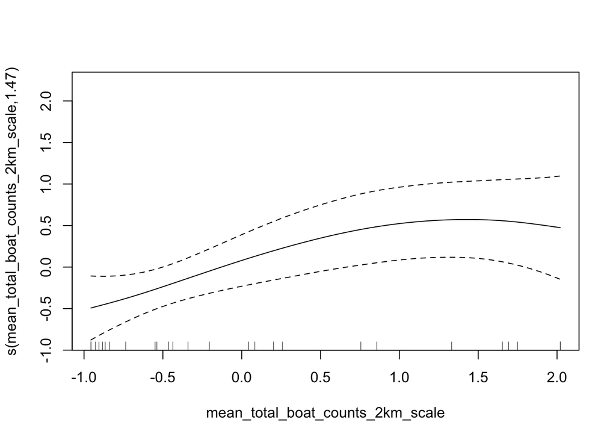

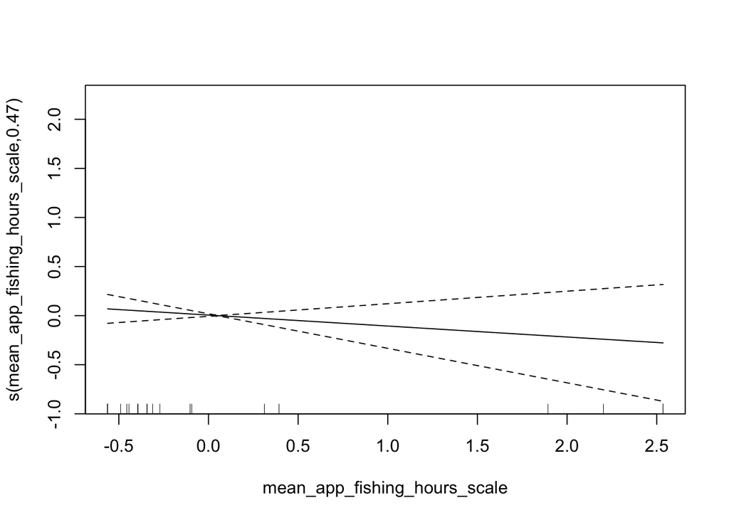

```
##
## Family: gaussian
## Link function: identity
##
## Formula:
## urch_sn_ratio_avg ~ s(sst_scale) + s(norm_openness_scale) + s(mean_total_boat_counts_2km_scale) +
##     s(mean_app_fishing_hours_scale)
##
## Parametric coefficients:
##             Estimate Std. Error t value Pr(>|t|)
## (Intercept)   0.7994     0.1500    5.33 2.89e-05 ***
## ---
## Signif. codes:  0 '***' 0.001 '**' 0.01 '*' 0.05 '.' 0.1 ' ' 1
##
## Approximate significance of smooth terms:
##                                        edf Ref.df     F p-value
## s(sst_scale)                        1.4699      9 0.444 0.07739 .
## s(norm_openness_scale)              0.8834      9 0.843 0.00597 **
## s(mean_total_boat_counts_2km_scale) 1.4670      9 0.869 0.01178 *
## s(mean_app_fishing_hours_scale)     0.4656      9 0.097 0.17490
## ---
## Signif. codes:  0 '***' 0.001 '**' 0.01 '*' 0.05 '.' 0.1 ' ' 1
##
## R-sq.(adj) =  0.507   Deviance explained = 59.2%
## -REML = 34.679  Scale est. = 0.58482   n = 26
```

Might need to omit mean apparent fishing hours as this improves the residuals and concurvity.

##### Testing the residuals for autocorrelation

```
##
##  Moran I test under randomisation
##
## data:  residuals_total_mod_2km_total_boats_avg
## weights: lw_avg
## n reduced by no-neighbour observations
##
## Moran I statistic standard deviate = 0.48894, p-value = 0.3124
## alternative hypothesis: greater
## sample estimates:
## Moran I statistic       Expectation          Variance
##        0.03033492       -0.11111111        0.08368882
```

```
##
##  Moran I test under randomisation
##
## data:  residuals_total_mod_2km_total_boats_avg
## weights: lw_inverse_avg
##
## Moran I statistic standard deviate = 0.21481, p-value = 0.415
## alternative hypothesis: greater
## sample estimates:
## Moran I statistic       Expectation          Variance
##      -0.024581001      -0.040000000       0.005152122
```

No spatial autocorrelation.

##### Testing the model for concurvity

```
## $worst
##                                             para s(sst_scale)
## para                                1.000000e+00 2.111799e-24
## s(sst_scale)                        2.106192e-24 1.000000e+00
## s(norm_openness_scale)              2.630097e-23 9.517659e-01
## s(mean_total_boat_counts_2km_scale) 1.139865e-22 9.757273e-01
## s(mean_app_fishing_hours_scale)     1.429330e-18 9.996369e-01
##                                     s(norm_openness_scale)
## para                                          2.633319e-23
## s(sst_scale)                                  9.517659e-01
## s(norm_openness_scale)                        1.000000e+00
## s(mean_total_boat_counts_2km_scale)           9.137082e-01
## s(mean_app_fishing_hours_scale)               9.129862e-01
##                                     s(mean_total_boat_counts_2km_scale)
## para                                                       1.139092e-22
## s(sst_scale)                                               9.757273e-01
## s(norm_openness_scale)                                     9.137082e-01
## s(mean_total_boat_counts_2km_scale)                        1.000000e+00
## s(mean_app_fishing_hours_scale)                            9.998498e-01
##                                     s(mean_app_fishing_hours_scale)
## para                                                   1.429339e-18
## s(sst_scale)                                           9.996369e-01
## s(norm_openness_scale)                                 9.129862e-01
## s(mean_total_boat_counts_2km_scale)                    9.998498e-01
## s(mean_app_fishing_hours_scale)                        1.000000e+00
##
## $observed
##                                             para s(sst_scale)
## para                                1.000000e+00 8.400005e-31
## s(sst_scale)                        2.106192e-24 1.000000e+00
## s(norm_openness_scale)              2.630097e-23 4.417974e-01
## s(mean_total_boat_counts_2km_scale) 1.139865e-22 6.603306e-01
## s(mean_app_fishing_hours_scale)     1.429330e-18 5.970571e-01
##                                     s(norm_openness_scale)
## para                                          1.895966e-33
## s(sst_scale)                                  4.948959e-01
## s(norm_openness_scale)                        1.000000e+00
## s(mean_total_boat_counts_2km_scale)           2.004568e-01
## s(mean_app_fishing_hours_scale)               2.048900e-01
##                                     s(mean_total_boat_counts_2km_scale)
```

[output cut: 22 more lines]

```
## s(norm_openness_scale)                        1.000000e+00
## s(mean_total_boat_counts_2km_scale)           2.218846e-01
## s(mean_app_fishing_hours_scale)               2.003710e-01
##                                     s(mean_total_boat_counts_2km_scale)
## para                                                       1.136659e-25
## s(sst_scale)                                               5.758790e-01
## s(norm_openness_scale)                                     3.489511e-01
## s(mean_total_boat_counts_2km_scale)                        1.000000e+00
## s(mean_app_fishing_hours_scale)                            6.064415e-01
##                                     s(mean_app_fishing_hours_scale)
## para                                                   1.313946e-22
## s(sst_scale)                                           3.517142e-01
## s(norm_openness_scale)                                 3.150262e-01
## s(mean_total_boat_counts_2km_scale)                    5.658275e-01
## s(mean_app_fishing_hours_scale)                        1.000000e+00
```

Some of the variables appear to have high concurvity scores in the worst case, but confidence intervals seem stable for the model plots. May need to get rid of the mean apparent fishing hours however. Since the concurvity was very high.

### Building GAMs on the urch sn ratio with TOTAL boats, avg transects, and no app hours

#### Model with 1 km total boats avg and no app hours

```r
total_mod_1km_total_boats_avg_no_hours <- gam(urch_sn_ratio_avg ~ s(sst_scale) +
                   s(norm_openness_scale) +
                   s(mean_total_boat_counts_1km_scale),
               data = env_mod_data_avg,
               family = gaussian(link = "identity"),
               method = 'REML',
               select = FALSE)
```

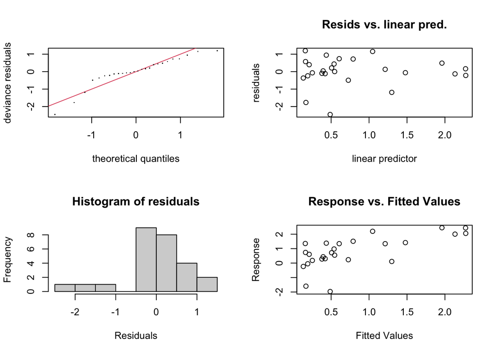

```
##
## Method: REML   Optimizer: outer newton
## full convergence after 13 iterations.
## Gradient range [-8.888439e-06,3.06792e-05]
## (score 35.19035 & scale 0.7817868).
## Hessian positive definite, eigenvalue range [7.934924e-06,11.00589].
## Model rank =  28 / 28
##
## Basis dimension (k) checking results. Low p-value (k-index<1) may
## indicate that k is too low, especially if edf is close to k'.
##
##                                       k'  edf k-index p-value
## s(sst_scale)                        9.00 1.51    1.12    0.66
## s(norm_openness_scale)              9.00 1.00    1.15    0.76
## s(mean_total_boat_counts_1km_scale) 9.00 1.00    1.13    0.76
```

```
##                           (Intercept)                        s(sst_scale).1
##                          7.993946e-01                          3.540184e-02
##                        s(sst_scale).2                        s(sst_scale).3
##                         -9.572533e-02                         -2.142882e-02
##                        s(sst_scale).4                        s(sst_scale).5
##                         -7.228466e-02                          7.081390e-02
##                        s(sst_scale).6                        s(sst_scale).7
##                          6.673904e-02                          6.153524e-02
##                        s(sst_scale).8                        s(sst_scale).9
##                         -4.035002e-01                         -1.419589e-03
##              s(norm_openness_scale).1              s(norm_openness_scale).2
##                         -8.007330e-07                          1.834556e-06
##              s(norm_openness_scale).3              s(norm_openness_scale).4
##                          8.650184e-07                         -1.129660e-06
##              s(norm_openness_scale).5              s(norm_openness_scale).6
##                          5.501478e-07                         -1.323203e-06
##              s(norm_openness_scale).7              s(norm_openness_scale).8
##                          1.117276e-06                         -5.974153e-06
##              s(norm_openness_scale).9 s(mean_total_boat_counts_1km_scale).1
##                          5.023489e-01                         -6.443264e-06
## s(mean_total_boat_counts_1km_scale).2 s(mean_total_boat_counts_1km_scale).3
##                          1.485131e-05                         -8.020580e-06
## s(mean_total_boat_counts_1km_scale).4 s(mean_total_boat_counts_1km_scale).5
##                          1.180930e-05                          3.864266e-06
## s(mean_total_boat_counts_1km_scale).6 s(mean_total_boat_counts_1km_scale).7
##                         -1.088064e-05                         -1.083881e-05
## s(mean_total_boat_counts_1km_scale).8 s(mean_total_boat_counts_1km_scale).9
##                          4.957957e-05                          2.557843e-01
```

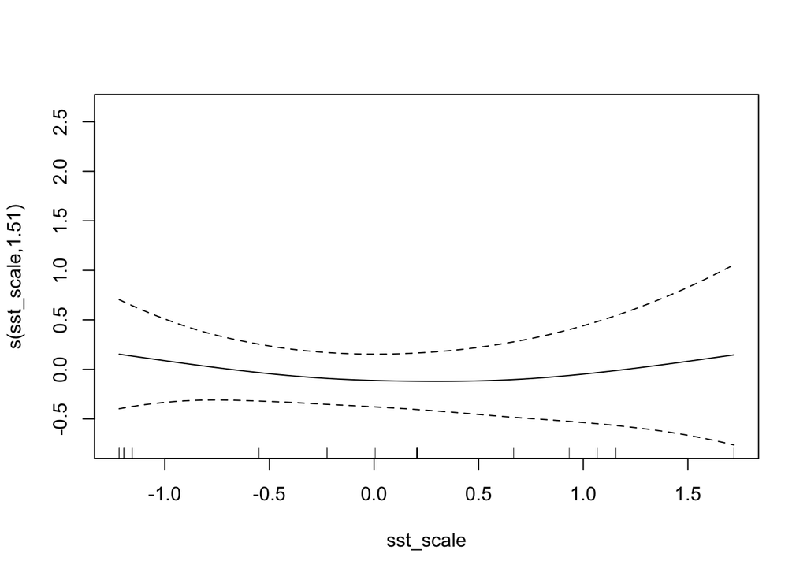

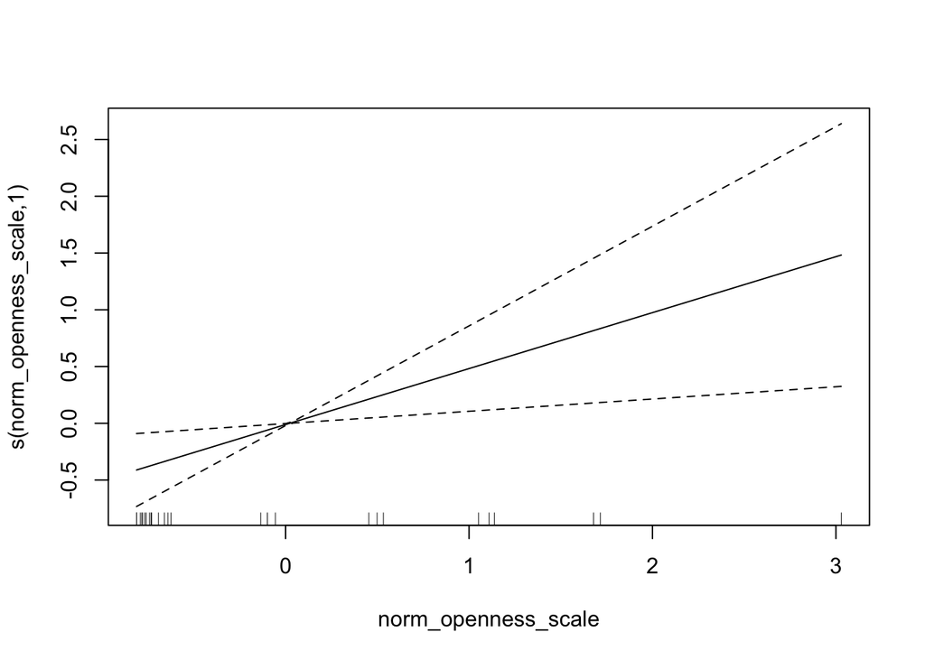

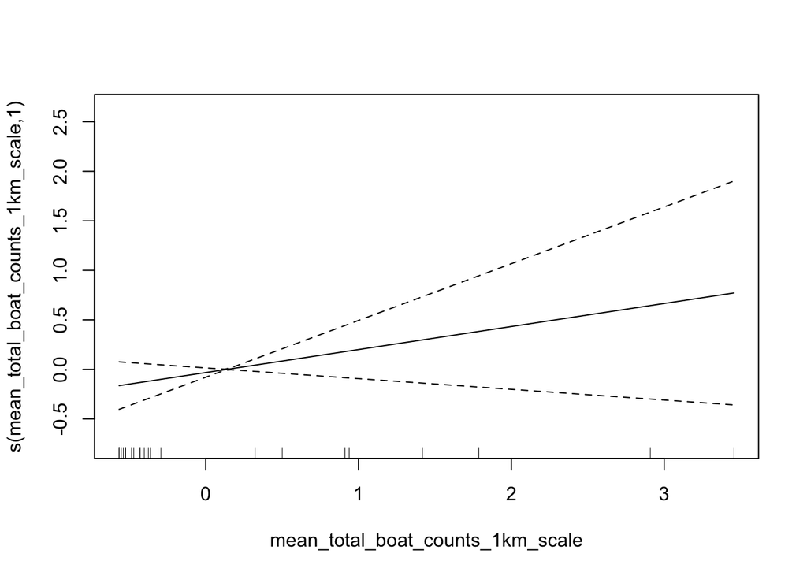

```
##
## Family: gaussian
## Link function: identity
##
## Formula:
## urch_sn_ratio_avg ~ s(sst_scale) + s(norm_openness_scale) + s(mean_total_boat_counts_1km_scale)
##
## Parametric coefficients:
##             Estimate Std. Error t value Pr(>|t|)
## (Intercept)   0.7994     0.1734    4.61 0.000143 ***
## ---
## Signif. codes:  0 '***' 0.001 '**' 0.01 '*' 0.05 '.' 0.1 ' ' 1
##
## Approximate significance of smooth terms:
##                                       edf Ref.df     F p-value
## s(sst_scale)                        1.508  1.825 0.310  0.6773
## s(norm_openness_scale)              1.000  1.000 6.563  0.0182 *
## s(mean_total_boat_counts_1km_scale) 1.000  1.000 1.864  0.1866
## ---
## Signif. codes:  0 '***' 0.001 '**' 0.01 '*' 0.05 '.' 0.1 ' ' 1
##
## R-sq.(adj) =  0.341   Deviance explained = 43.3%
## -REML =  35.19  Scale est. = 0.78179   n = 26
```

##### Testing the residuals for autocorrelation

```
##
##  Moran I test under randomisation
##
## data:  residuals_total_mod_1km_total_boats_avg_no_hours
## weights: lw_avg
## n reduced by no-neighbour observations
##
## Moran I statistic standard deviate = 0.45035, p-value = 0.3262
## alternative hypothesis: greater
## sample estimates:
## Moran I statistic       Expectation          Variance
##        0.03210435       -0.11111111        0.10113146
```

```
##
##  Moran I test under randomisation
##
## data:  residuals_total_mod_1km_total_boats_avg_no_hours
## weights: lw_inverse_avg
##
## Moran I statistic standard deviate = 0.49686, p-value = 0.3096
## alternative hypothesis: greater
## sample estimates:
## Moran I statistic       Expectation          Variance
##      -0.003824766      -0.040000000       0.005300900
```

No spatial autocorrelation.

##### Testing the model for concurvity

```
## $worst
##                                             para s(sst_scale)
## para                                1.000000e+00 2.111799e-24
## s(sst_scale)                        2.106192e-24 1.000000e+00
## s(norm_openness_scale)              2.630097e-23 9.517659e-01
## s(mean_total_boat_counts_1km_scale) 5.824135e-18 8.292860e-01
##                                     s(norm_openness_scale)
## para                                          2.633319e-23
## s(sst_scale)                                  9.517659e-01
## s(norm_openness_scale)                        1.000000e+00
## s(mean_total_boat_counts_1km_scale)           9.744619e-01
##                                     s(mean_total_boat_counts_1km_scale)
## para                                                       5.824126e-18
## s(sst_scale)                                               8.292860e-01
## s(norm_openness_scale)                                     9.744619e-01
## s(mean_total_boat_counts_1km_scale)                        1.000000e+00
##
## $observed
##                                             para s(sst_scale)
## para                                1.000000e+00 5.069482e-31
## s(sst_scale)                        2.106192e-24 1.000000e+00
## s(norm_openness_scale)              2.630097e-23 4.446953e-01
## s(mean_total_boat_counts_1km_scale) 5.824135e-18 3.308795e-01
##                                     s(norm_openness_scale)
## para                                          1.896186e-33
## s(sst_scale)                                  4.948962e-01
## s(norm_openness_scale)                        1.000000e+00
## s(mean_total_boat_counts_1km_scale)           2.869158e-01
##                                     s(mean_total_boat_counts_1km_scale)
## para                                                       6.219542e-33
## s(sst_scale)                                               5.100115e-01
## s(norm_openness_scale)                                     6.590093e-01
## s(mean_total_boat_counts_1km_scale)                        1.000000e+00
##
## $estimate
##                                             para s(sst_scale)
## para                                1.000000e+00 3.685004e-28
## s(sst_scale)                        2.106192e-24 1.000000e+00
## s(norm_openness_scale)              2.630097e-23 4.468583e-01
## s(mean_total_boat_counts_1km_scale) 5.824135e-18 2.786454e-01
##                                     s(norm_openness_scale)
## para                                          7.676177e-27
## s(sst_scale)                                  4.811534e-01
## s(norm_openness_scale)                        1.000000e+00
## s(mean_total_boat_counts_1km_scale)           2.322177e-01
##                                     s(mean_total_boat_counts_1km_scale)
## para                                                       1.033135e-21
## s(sst_scale)                                               4.535350e-01
## s(norm_openness_scale)                                     7.275295e-01
## s(mean_total_boat_counts_1km_scale)                        1.000000e+00
```

Still high concurvity but it is improved slightly and the other ones are not as high as the mean apparent fishing hours were.

#### Model with 1.5 km total boats avg and no app hours

```r
total_mod_1.5km_total_boats_avg_no_hours <- gam(urch_sn_ratio_avg ~ s(sst_scale) +
                   s(norm_openness_scale) +
                   s(mean_total_boat_counts_1.5km_scale),
               data = env_mod_data_avg,
               family = gaussian(link = "identity"),
               method = 'REML',
               select = FALSE)
```

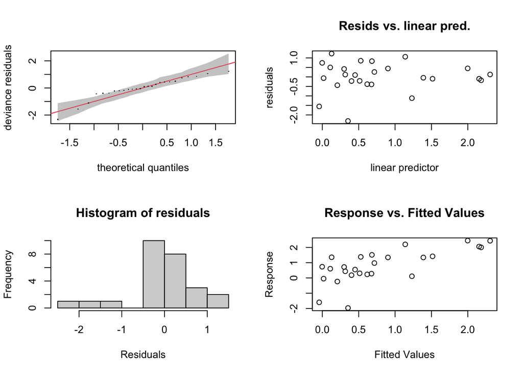

```
##
## Method: REML   Optimizer: outer newton
## full convergence after 11 iterations.
## Gradient range [-1.235592e-05,1.602376e-06]
## (score 34.6927 & scale 0.7228559).
## Hessian positive definite, eigenvalue range [1.235567e-05,11.01435].
## Model rank =  28 / 28
##
## Basis dimension (k) checking results. Low p-value (k-index<1) may
## indicate that k is too low, especially if edf is close to k'.
##
##                                         k'  edf k-index p-value
## s(sst_scale)                          9.00 1.77    1.09    0.63
## s(norm_openness_scale)                9.00 1.00    1.15    0.70
## s(mean_total_boat_counts_1.5km_scale) 9.00 1.19    1.16    0.72
```

```
##                             (Intercept)                          s(sst_scale).1
##                            7.993946e-01                            6.422288e-02
##                          s(sst_scale).2                          s(sst_scale).3
##                           -1.554781e-01                           -3.528983e-02
##                          s(sst_scale).4                          s(sst_scale).5
##                           -1.205085e-01                            1.202318e-01
##                          s(sst_scale).6                          s(sst_scale).7
##                            1.133003e-01                            1.033952e-01
##                          s(sst_scale).8                          s(sst_scale).9
##                           -6.874663e-01                            4.785977e-02
##                s(norm_openness_scale).1                s(norm_openness_scale).2
##                           -7.678096e-07                            2.051944e-06
##                s(norm_openness_scale).3                s(norm_openness_scale).4
##                            9.691586e-07                           -1.233451e-06
##                s(norm_openness_scale).5                s(norm_openness_scale).6
##                            5.900131e-07                           -1.413361e-06
##                s(norm_openness_scale).7                s(norm_openness_scale).8
##                            1.195860e-06                           -6.308657e-06
##                s(norm_openness_scale).9 s(mean_total_boat_counts_1.5km_scale).1
##                            5.089110e-01                            2.882800e-02
## s(mean_total_boat_counts_1.5km_scale).2 s(mean_total_boat_counts_1.5km_scale).3
##                           -3.844154e-02                           -1.969152e-04
## s(mean_total_boat_counts_1.5km_scale).4 s(mean_total_boat_counts_1.5km_scale).5
##                            3.284861e-02                            5.811871e-03
## s(mean_total_boat_counts_1.5km_scale).6 s(mean_total_boat_counts_1.5km_scale).7
##                           -3.217362e-02                           -2.691738e-02
## s(mean_total_boat_counts_1.5km_scale).8 s(mean_total_boat_counts_1.5km_scale).9
##                            1.387431e-01                            3.262989e-01
```

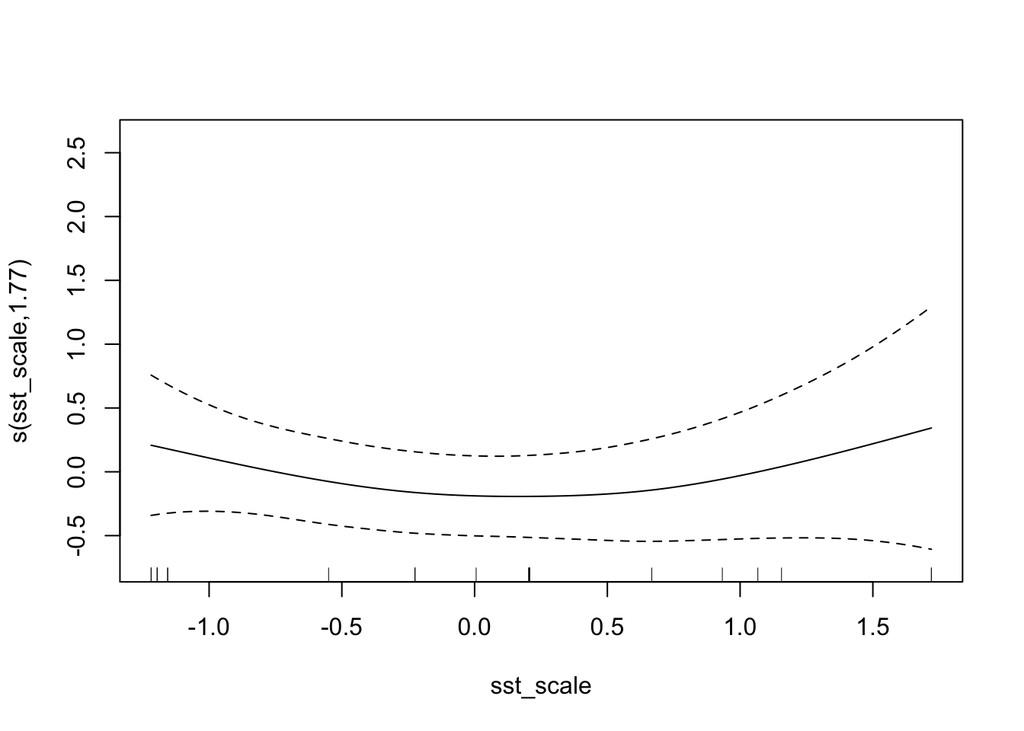

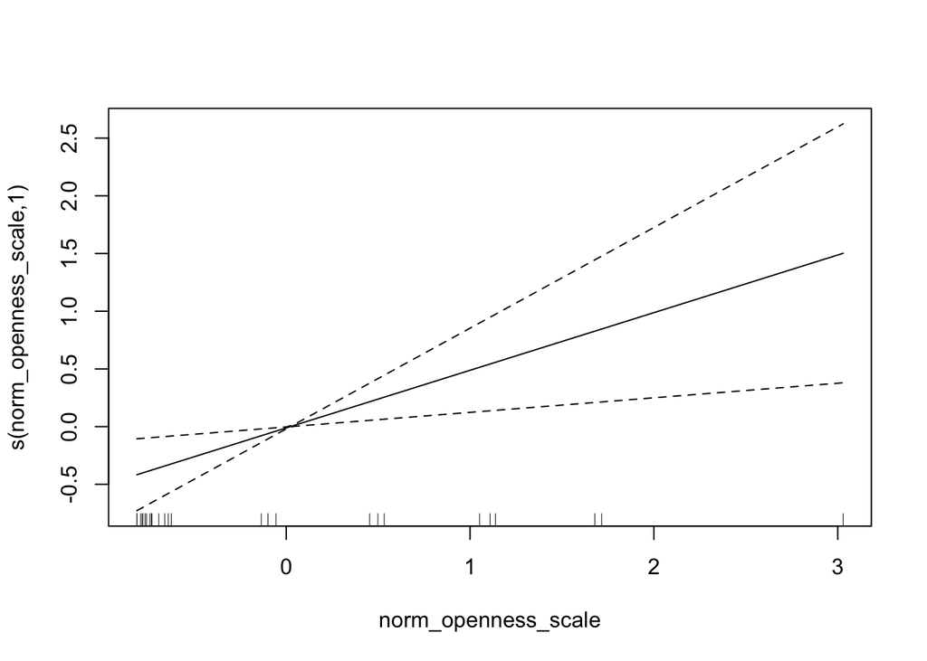

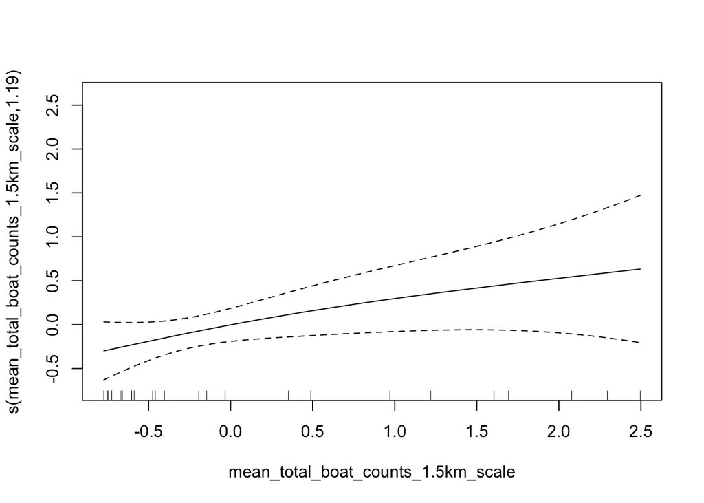

```
##
## Family: gaussian
## Link function: identity
##
## Formula:
## urch_sn_ratio_avg ~ s(sst_scale) + s(norm_openness_scale) + s(mean_total_boat_counts_1.5km_scale)
##
## Parametric coefficients:
##             Estimate Std. Error t value Pr(>|t|)
## (Intercept)   0.7994     0.1667   4.794  9.7e-05 ***
## ---
## Signif. codes:  0 '***' 0.001 '**' 0.01 '*' 0.05 '.' 0.1 ' ' 1
##
## Approximate significance of smooth terms:
##                                         edf Ref.df     F p-value
## s(sst_scale)                          1.765  2.137 0.783  0.4522
## s(norm_openness_scale)                1.000  1.000 7.167  0.0141 *
## s(mean_total_boat_counts_1.5km_scale) 1.185  1.344 2.018  0.1289
## ---
## Signif. codes:  0 '***' 0.001 '**' 0.01 '*' 0.05 '.' 0.1 ' ' 1
##
## R-sq.(adj) =  0.391   Deviance explained = 48.7%
## -REML = 34.693  Scale est. = 0.72286   n = 26
```

##### Testing the residuals for autocorrelation

```
##
##  Moran I test under randomisation
##
## data:  residuals_total_mod_1.5km_total_boats_avg_no_hours
## weights: lw_avg
## n reduced by no-neighbour observations
##
## Moran I statistic standard deviate = 0.46863, p-value = 0.3197
## alternative hypothesis: greater
## sample estimates:
## Moran I statistic       Expectation          Variance
##        0.04404358       -0.11111111        0.10961444
```

```
##
##  Moran I test under randomisation
##
## data:  residuals_total_mod_1.5km_total_boats_avg_no_hours
## weights: lw_inverse_avg
##
## Moran I statistic standard deviate = 0.48914, p-value = 0.3124
## alternative hypothesis: greater
## sample estimates:
## Moran I statistic       Expectation          Variance
##      -0.004144769      -0.040000000       0.005373257
```

No spatial autocorrelation.

##### Testing the model for concurvity

```
## $worst
##                                               para s(sst_scale)
## para                                  1.000000e+00 2.111799e-24
## s(sst_scale)                          2.106192e-24 1.000000e+00
## s(norm_openness_scale)                2.630097e-23 9.517659e-01
## s(mean_total_boat_counts_1.5km_scale) 2.065509e-21 8.171219e-01
##                                       s(norm_openness_scale)
## para                                            2.633319e-23
## s(sst_scale)                                    9.517659e-01
## s(norm_openness_scale)                          1.000000e+00
## s(mean_total_boat_counts_1.5km_scale)           8.758240e-01
##                                       s(mean_total_boat_counts_1.5km_scale)
## para                                                           2.065622e-21
## s(sst_scale)                                                   8.171219e-01
## s(norm_openness_scale)                                         8.758240e-01
## s(mean_total_boat_counts_1.5km_scale)                          1.000000e+00
##
## $observed
##                                               para s(sst_scale)
## para                                  1.000000e+00 3.735125e-31
## s(sst_scale)                          2.106192e-24 1.000000e+00
## s(norm_openness_scale)                2.630097e-23 3.724481e-01
## s(mean_total_boat_counts_1.5km_scale) 2.065509e-21 3.156000e-01
##                                       s(norm_openness_scale)
## para                                            1.896270e-33
## s(sst_scale)                                    4.948962e-01
## s(norm_openness_scale)                          1.000000e+00
## s(mean_total_boat_counts_1.5km_scale)           6.330597e-01
##                                       s(mean_total_boat_counts_1.5km_scale)
## para                                                           3.546328e-30
## s(sst_scale)                                                   5.204790e-01
## s(norm_openness_scale)                                         4.540374e-01
## s(mean_total_boat_counts_1.5km_scale)                          1.000000e+00
##
## $estimate
##                                               para s(sst_scale)
## para                                  1.000000e+00 3.685004e-28
## s(sst_scale)                          2.106192e-24 1.000000e+00
## s(norm_openness_scale)                2.630097e-23 4.468583e-01
## s(mean_total_boat_counts_1.5km_scale) 2.065509e-21 3.488698e-01
##                                       s(norm_openness_scale)
## para                                            7.676177e-27
## s(sst_scale)                                    4.811534e-01
## s(norm_openness_scale)                          1.000000e+00
## s(mean_total_boat_counts_1.5km_scale)           5.487616e-01
##                                       s(mean_total_boat_counts_1.5km_scale)
## para                                                           9.858033e-25
## s(sst_scale)                                                   4.753316e-01
## s(norm_openness_scale)                                         5.115010e-01
## s(mean_total_boat_counts_1.5km_scale)                          1.000000e+00
```

Still high concurvity but it is improved slightly and the other ones are not as high as the mean apparent fishing hours were.

#### Model with 2 km total boats avg

```r
total_mod_2km_total_boats_avg_no_hours <- gam(urch_sn_ratio_avg ~ s(sst_scale) +
                   s(norm_openness_scale) +
                   s(mean_total_boat_counts_2km_scale),
               data = env_mod_data_avg,
               family = gaussian(link = "identity"),
               method = 'REML',
               select = FALSE)
```

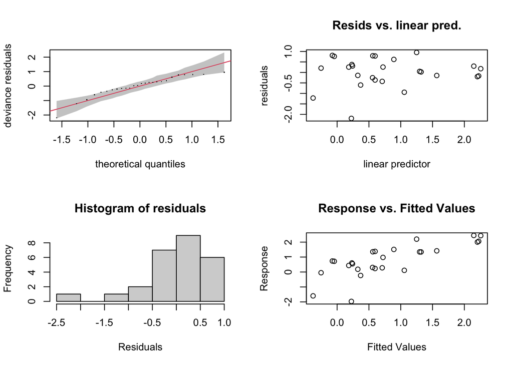

```
##
## Method: REML   Optimizer: outer newton
## full convergence after 11 iterations.
## Gradient range [-1.274647e-05,1.203189e-06]
## (score 33.4758 & scale 0.6073103).
## Hessian positive definite, eigenvalue range [1.27462e-05,11.03602].
## Model rank =  28 / 28
##
## Basis dimension (k) checking results. Low p-value (k-index<1) may
## indicate that k is too low, especially if edf is close to k'.
##
##                                       k'  edf k-index p-value
## s(sst_scale)                        9.00 2.09    1.13    0.67
## s(norm_openness_scale)              9.00 1.00    1.14    0.70
## s(mean_total_boat_counts_2km_scale) 9.00 1.60    1.33    0.92
```

```
##                           (Intercept)                        s(sst_scale).1
##                          7.993946e-01                          1.793280e-01
##                        s(sst_scale).2                        s(sst_scale).3
##                         -2.197151e-01                         -5.429117e-02
##                        s(sst_scale).4                        s(sst_scale).5
##                         -1.923434e-01                          1.978700e-01
##                        s(sst_scale).6                        s(sst_scale).7
##                          1.845023e-01                          1.653625e-01
##                        s(sst_scale).8                        s(sst_scale).9
##                         -1.132000e+00                          1.822269e-01
##              s(norm_openness_scale).1              s(norm_openness_scale).2
##                          2.329147e-09                          1.551355e-06
##              s(norm_openness_scale).3              s(norm_openness_scale).4
##                          7.911962e-07                         -1.022431e-06
##              s(norm_openness_scale).5              s(norm_openness_scale).6
##                          4.871246e-07                         -1.160852e-06
##              s(norm_openness_scale).7              s(norm_openness_scale).8
##                          9.873674e-07                         -5.460178e-06
##              s(norm_openness_scale).9 s(mean_total_boat_counts_2km_scale).1
##                          4.942910e-01                          4.015259e-02
## s(mean_total_boat_counts_2km_scale).2 s(mean_total_boat_counts_2km_scale).3
##                          1.209739e-01                          5.397543e-02
## s(mean_total_boat_counts_2km_scale).4 s(mean_total_boat_counts_2km_scale).5
##                          1.065209e-01                          1.570087e-02
## s(mean_total_boat_counts_2km_scale).6 s(mean_total_boat_counts_2km_scale).7
##                          9.692345e-02                         -8.875824e-02
## s(mean_total_boat_counts_2km_scale).8 s(mean_total_boat_counts_2km_scale).9
##                          5.143020e-01                          4.107553e-01
```

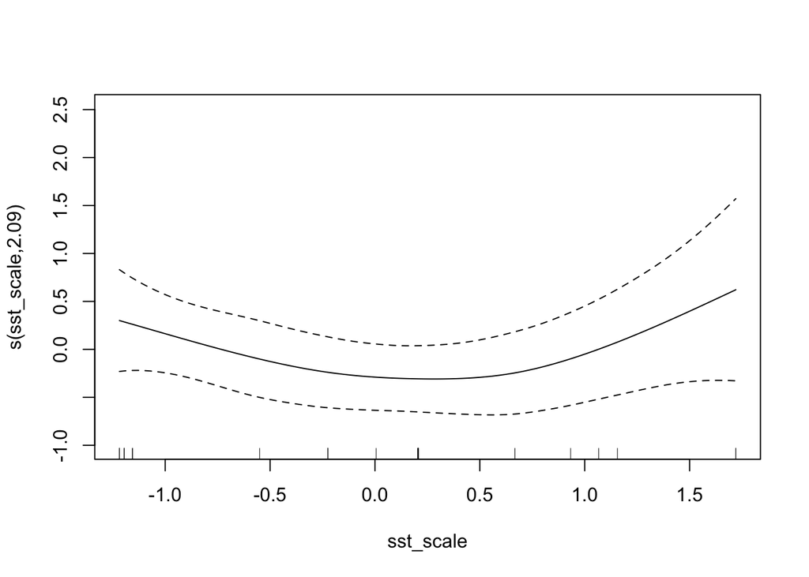

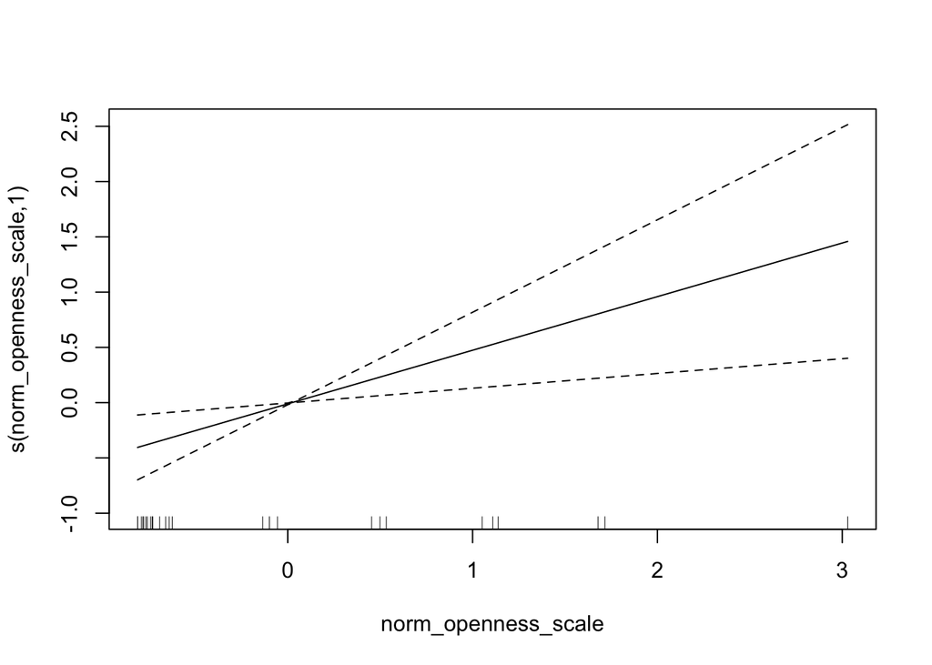

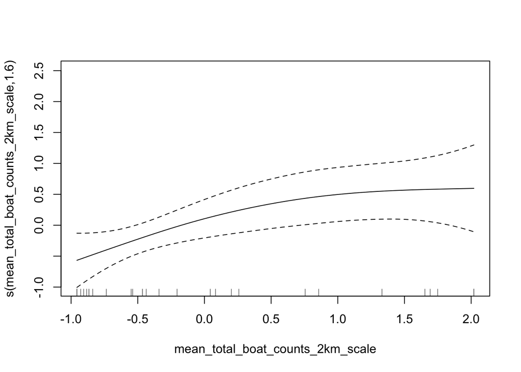

```
##
## Family: gaussian
## Link function: identity
##
## Formula:
## urch_sn_ratio_avg ~ s(sst_scale) + s(norm_openness_scale) + s(mean_total_boat_counts_2km_scale)
##
## Parametric coefficients:
##             Estimate Std. Error t value Pr(>|t|)
## (Intercept)   0.7994     0.1528    5.23 3.87e-05 ***
## ---
## Signif. codes:  0 '***' 0.001 '**' 0.01 '*' 0.05 '.' 0.1 ' ' 1
##
## Approximate significance of smooth terms:
##                                       edf Ref.df     F p-value
## s(sst_scale)                        2.087  2.504 1.413  0.2178
## s(norm_openness_scale)              1.000  1.000 7.616  0.0121 *
## s(mean_total_boat_counts_2km_scale) 1.604  1.958 3.453  0.0422 *
## ---
## Signif. codes:  0 '***' 0.001 '**' 0.01 '*' 0.05 '.' 0.1 ' ' 1
##
## R-sq.(adj) =  0.488   Deviance explained = 58.4%
## -REML = 33.476  Scale est. = 0.60731   n = 26
```

##### Testing the residuals for autocorrelation

```
##
##  Moran I test under randomisation
##
## data:  residuals_total_mod_2km_total_boats_avg_no_hours
## weights: lw_avg
## n reduced by no-neighbour observations
##
## Moran I statistic standard deviate = 0.39485, p-value = 0.3465
## alternative hypothesis: greater
## sample estimates:
## Moran I statistic       Expectation          Variance
##        0.01445443       -0.11111111        0.10112825
```

```
##
##  Moran I test under randomisation
##
## data:  residuals_total_mod_2km_total_boats_avg_no_hours
## weights: lw_inverse_avg
##
## Moran I statistic standard deviate = -0.10644, p-value = 0.5424
## alternative hypothesis: greater
## sample estimates:
## Moran I statistic       Expectation          Variance
##      -0.047749808      -0.040000000       0.005300873
```

No spatial autocorrelation.

##### Testing the model for concurvity

```
## $worst
##                                             para s(sst_scale)
## para                                1.000000e+00 2.111799e-24
## s(sst_scale)                        2.106192e-24 1.000000e+00
## s(norm_openness_scale)              2.630097e-23 9.517659e-01
## s(mean_total_boat_counts_2km_scale) 1.139865e-22 9.757273e-01
##                                     s(norm_openness_scale)
## para                                          2.633319e-23
## s(sst_scale)                                  9.517659e-01
## s(norm_openness_scale)                        1.000000e+00
## s(mean_total_boat_counts_2km_scale)           9.137082e-01
##                                     s(mean_total_boat_counts_2km_scale)
## para                                                       1.139092e-22
## s(sst_scale)                                               9.757273e-01
## s(norm_openness_scale)                                     9.137082e-01
## s(mean_total_boat_counts_2km_scale)                        1.000000e+00
##
## $observed
##                                             para s(sst_scale)
## para                                1.000000e+00 1.301130e-31
## s(sst_scale)                        2.106192e-24 1.000000e+00
## s(norm_openness_scale)              2.630097e-23 3.489797e-01
## s(mean_total_boat_counts_2km_scale) 1.139865e-22 6.786669e-01
##                                     s(norm_openness_scale)
## para                                          1.896369e-33
## s(sst_scale)                                  4.948961e-01
## s(norm_openness_scale)                        1.000000e+00
## s(mean_total_boat_counts_2km_scale)           2.004567e-01
##                                     s(mean_total_boat_counts_2km_scale)
## para                                                       3.728576e-30
## s(sst_scale)                                               6.017723e-01
## s(norm_openness_scale)                                     3.694894e-01
## s(mean_total_boat_counts_2km_scale)                        1.000000e+00
##
## $estimate
##                                             para s(sst_scale)
## para                                1.000000e+00 3.685004e-28
## s(sst_scale)                        2.106192e-24 1.000000e+00
## s(norm_openness_scale)              2.630097e-23 4.468583e-01
## s(mean_total_boat_counts_2km_scale) 1.139865e-22 3.799617e-01
##                                     s(norm_openness_scale)
## para                                          7.676177e-27
## s(sst_scale)                                  4.811534e-01
## s(norm_openness_scale)                        1.000000e+00
## s(mean_total_boat_counts_2km_scale)           2.218846e-01
##                                     s(mean_total_boat_counts_2km_scale)
## para                                                       1.136659e-25
## s(sst_scale)                                               5.758790e-01
## s(norm_openness_scale)                                     3.489511e-01
## s(mean_total_boat_counts_2km_scale)                        1.000000e+00
```

Still high concurvity but it is improved slightly and the other ones are not as high as the mean apparent fishing hours were.

### Building GAMs on the urch sn ratio with TOTAL boats and RE of transect/site

This method appears to present some issues. All of the other variables become insignificant and site code is significant. Additionally, the deviance explained rises to ~90-95 % which seems like the model is simply fitting for every individual point.

#### Model with 1 km total boats and RE of transect

```r
total_mod_1km_total_boats_transect <- gam(urch_sn_ratio ~ s(sst_scale) +
                   s(norm_openness_scale) +
                   s(mean_total_boat_counts_1km_scale)+
                   s(mean_app_fishing_hours_scale)+
                     s(site_code, bs = "re"),
               data = env_mod_data,
               family = gaussian(link = "identity"),
               method = 'REML',
               select = TRUE)
```

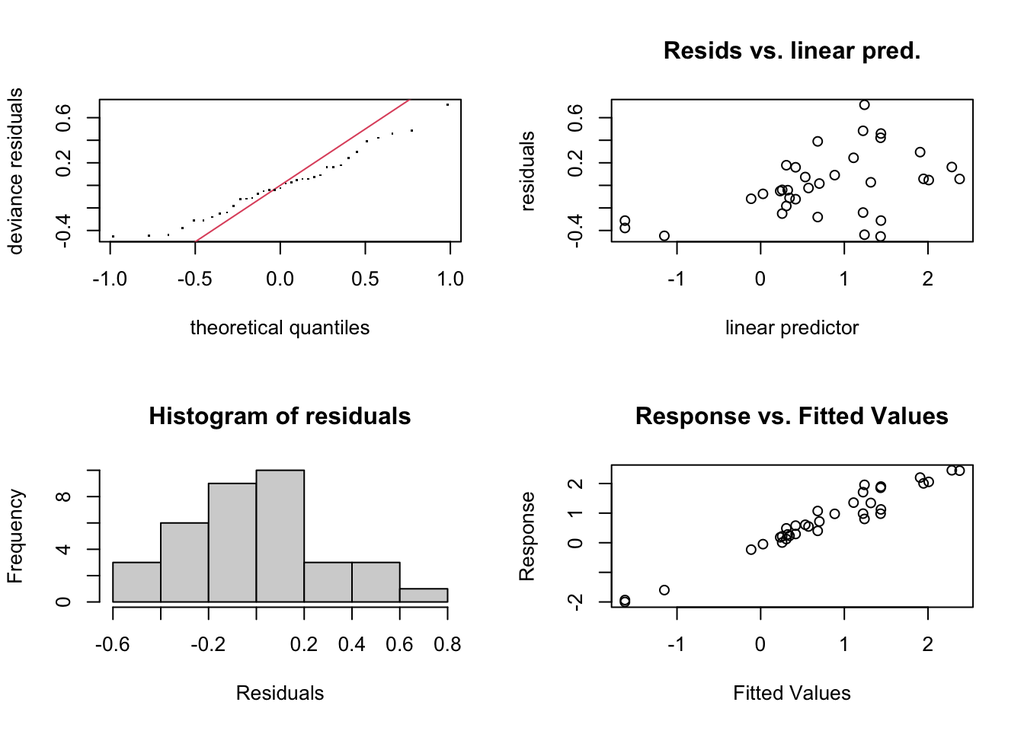

```
##
## Method: REML   Optimizer: outer newton
## full convergence after 17 iterations.
## Gradient range [-1.247994e-05,2.500459e-05]
## (score 44.96498 & scale 0.2019405).
## Hessian positive definite, eigenvalue range [2.319304e-07,22.95209].
## Model rank =  63 / 63
##
## Basis dimension (k) checking results. Low p-value (k-index<1) may
## indicate that k is too low, especially if edf is close to k'.
##
##                                           k'      edf k-index p-value
## s(sst_scale)                        9.00e+00 3.55e-05    1.14    0.77
## s(norm_openness_scale)              9.00e+00 8.95e-01    1.18    0.81
## s(mean_total_boat_counts_1km_scale) 9.00e+00 5.82e-01    1.16    0.76
## s(mean_app_fishing_hours_scale)     9.00e+00 1.96e-06    1.30    0.89
## s(site_code)                        2.60e+01 1.88e+01      NA      NA
```

```
##                           (Intercept)                        s(sst_scale).1
##                          7.633887e-01                          2.614494e-06
##                        s(sst_scale).2                        s(sst_scale).3
##                         -1.867628e-06                         -9.387340e-07
##                        s(sst_scale).4                        s(sst_scale).5
##                         -1.979995e-06                          1.946238e-06
##                        s(sst_scale).6                        s(sst_scale).7
##                          1.642271e-06                          1.280251e-06
##                        s(sst_scale).8                        s(sst_scale).9
##                         -1.083328e-05                         -6.440114e-08
##              s(norm_openness_scale).1              s(norm_openness_scale).2
##                         -5.097474e-06                          2.467732e-06
##              s(norm_openness_scale).3              s(norm_openness_scale).4
##                          9.238993e-07                         -1.181486e-06
##              s(norm_openness_scale).5              s(norm_openness_scale).6
##                          2.065003e-07                         -5.390451e-07
##              s(norm_openness_scale).7              s(norm_openness_scale).8
##                          5.474319e-07                          1.302511e-06
##              s(norm_openness_scale).9 s(mean_total_boat_counts_1km_scale).1
##                          4.891165e-01                          7.994598e-08
## s(mean_total_boat_counts_1km_scale).2 s(mean_total_boat_counts_1km_scale).3
##                          3.072677e-07                         -1.083448e-07
## s(mean_total_boat_counts_1km_scale).4 s(mean_total_boat_counts_1km_scale).5
##                          1.970006e-07                          1.055332e-07
## s(mean_total_boat_counts_1km_scale).6 s(mean_total_boat_counts_1km_scale).7
##                         -2.218300e-07                         -2.116706e-07
## s(mean_total_boat_counts_1km_scale).8 s(mean_total_boat_counts_1km_scale).9
##                          1.154160e-06                          1.504310e-01
##     s(mean_app_fishing_hours_scale).1     s(mean_app_fishing_hours_scale).2
##                         -9.406901e-08                          1.692196e-08
##     s(mean_app_fishing_hours_scale).3     s(mean_app_fishing_hours_scale).4
##                         -4.393334e-08                         -2.876953e-08
##     s(mean_app_fishing_hours_scale).5     s(mean_app_fishing_hours_scale).6
##                          3.250224e-08                          3.725189e-08
##     s(mean_app_fishing_hours_scale).7     s(mean_app_fishing_hours_scale).8
##                          3.629294e-08                         -1.909471e-07
##     s(mean_app_fishing_hours_scale).9                        s(site_code).1
##                         -1.202421e-07                         -9.480230e-01
##                        s(site_code).2                        s(site_code).3
##                          7.970685e-01                          3.563699e-01
```

[output cut: 9 more lines]

```
##                         -3.631440e-01                          9.618031e-01
##                       s(site_code).14                       s(site_code).15
##                          8.898705e-02                         -1.388739e-01
##                       s(site_code).16                       s(site_code).17
##                          1.531932e-01                         -1.014892e-01
##                       s(site_code).18                       s(site_code).19
##                          7.922473e-01                         -2.252566e+00
##                       s(site_code).20                       s(site_code).21
##                         -7.650636e-02                          2.966152e-01
##                       s(site_code).22                       s(site_code).23
##                          5.306002e-01                          1.232602e-01
##                       s(site_code).24                       s(site_code).25
##                          9.038498e-01                         -1.371632e-02
##                       s(site_code).26
##                          1.886358e-01
```

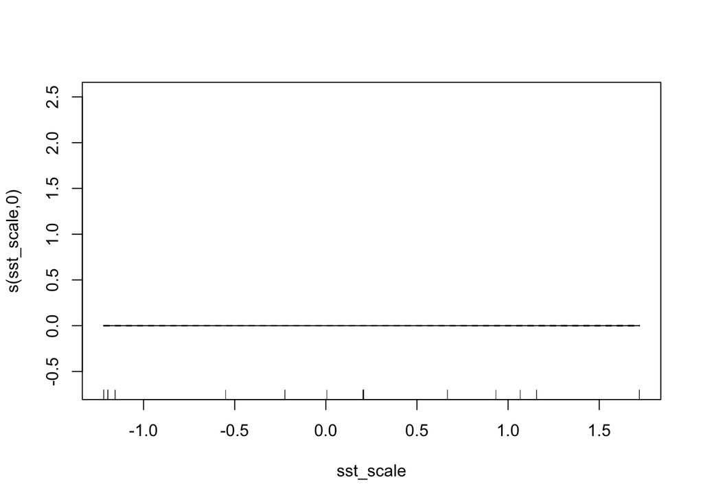

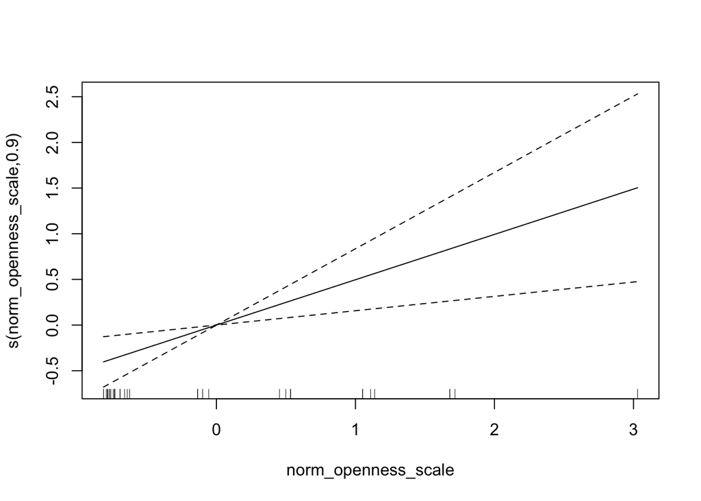

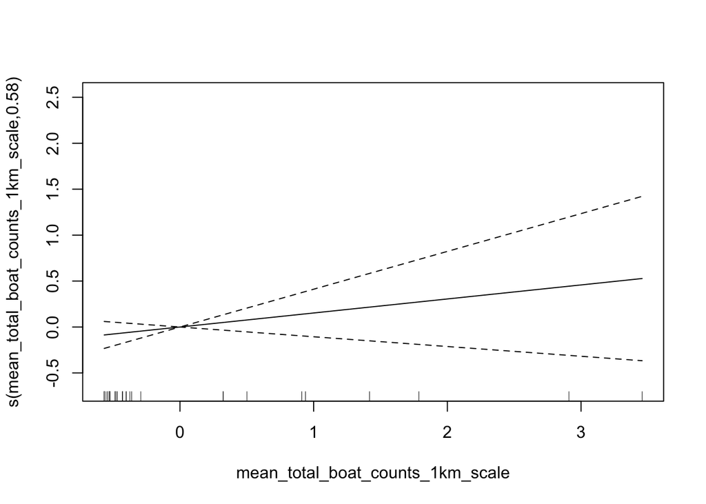

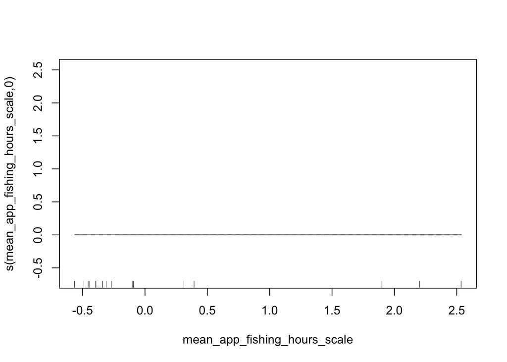

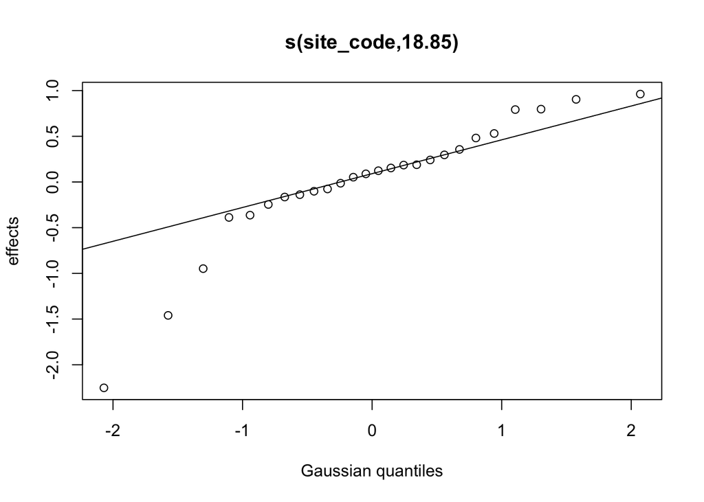

```
##
## Family: gaussian
## Link function: identity
##
## Formula:
## urch_sn_ratio ~ s(sst_scale) + s(norm_openness_scale) + s(mean_total_boat_counts_1km_scale) +
##     s(mean_app_fishing_hours_scale) + s(site_code, bs = "re")
##
## Parametric coefficients:
##             Estimate Std. Error t value Pr(>|t|)
## (Intercept)   0.7634     0.1785   4.277 0.000808 ***
## ---
## Signif. codes:  0 '***' 0.001 '**' 0.01 '*' 0.05 '.' 0.1 ' ' 1
##
## Approximate significance of smooth terms:
##                                           edf Ref.df      F p-value
## s(sst_scale)                        3.554e-05      9  0.000  0.9813
## s(norm_openness_scale)              8.954e-01      9 25.057  0.7213
## s(mean_total_boat_counts_1km_scale) 5.819e-01      8  2.238  0.9077
## s(mean_app_fishing_hours_scale)     1.961e-06      9  0.000  0.9999
## s(site_code)                        1.885e+01     25  5.169  0.0139 *
## ---
## Signif. codes:  0 '***' 0.001 '**' 0.01 '*' 0.05 '.' 0.1 ' ' 1
##
## R-sq.(adj) =  0.835   Deviance explained = 93.4%
## -REML = 44.965  Scale est. = 0.20194   n = 35
```

##### Testing the residuals for autocorrelation

```
##
##  Moran I test under randomisation
##
## data:  residuals_total_mod_1km_total_boats_transect
## weights: lw
## n reduced by no-neighbour observations
##
## Moran I statistic standard deviate = -1.6064, p-value = 0.9459
## alternative hypothesis: greater
## sample estimates:
## Moran I statistic       Expectation          Variance
##       -0.57756830       -0.05882353        0.10428236
```

```
##
##  Moran I test under randomisation
##
## data:  residuals_total_mod_1km_total_boats_transect
## weights: lw_inverse
##
## Moran I statistic standard deviate = -3.1647, p-value = 0.9992
## alternative hypothesis: greater
## sample estimates:
## Moran I statistic       Expectation          Variance
##       -0.56829887       -0.02941176        0.02899628
```

No autocorrelation.

##### Testing the model for concurvity

```
## $worst
##                                             para s(sst_scale)
## para                                1.000000e+00 4.176841e-24
## s(sst_scale)                        4.182745e-24 1.000000e+00
## s(norm_openness_scale)              1.365135e-17 9.527043e-01
## s(mean_total_boat_counts_1km_scale) 8.105300e-18 8.466783e-01
## s(mean_app_fishing_hours_scale)     6.545436e-17 9.996134e-01
## s(site_code)                        1.000000e+00 1.000000e+00
##                                     s(norm_openness_scale)
## para                                          1.365142e-17
## s(sst_scale)                                  9.527043e-01
## s(norm_openness_scale)                        1.000000e+00
## s(mean_total_boat_counts_1km_scale)           9.705147e-01
## s(mean_app_fishing_hours_scale)               8.987165e-01
## s(site_code)                                  1.000000e+00
##                                     s(mean_total_boat_counts_1km_scale)
## para                                                       8.105327e-18
## s(sst_scale)                                               8.466783e-01
## s(norm_openness_scale)                                     9.705147e-01
## s(mean_total_boat_counts_1km_scale)                        1.000000e+00
## s(mean_app_fishing_hours_scale)                            9.999935e-01
## s(site_code)                                               1.000000e+00
##                                     s(mean_app_fishing_hours_scale)
## para                                                   6.545414e-17
## s(sst_scale)                                           9.996134e-01
## s(norm_openness_scale)                                 8.987165e-01
## s(mean_total_boat_counts_1km_scale)                    9.999935e-01
## s(mean_app_fishing_hours_scale)                        1.000000e+00
## s(site_code)                                           1.000000e+00
##                                     s(site_code)
## para                                           1
## s(sst_scale)                                   1
## s(norm_openness_scale)                         1
## s(mean_total_boat_counts_1km_scale)            1
## s(mean_app_fishing_hours_scale)                1
## s(site_code)                                   1
##
## $observed
##                                             para s(sst_scale)
## para                                1.000000e+00 1.636933e-30
```

[output cut: 55 more lines]

```
## s(site_code)                                               1.000000e+00
##                                     s(mean_app_fishing_hours_scale)
## para                                                   5.634184e-21
## s(sst_scale)                                           4.095968e-01
## s(norm_openness_scale)                                 2.390114e-01
## s(mean_total_boat_counts_1km_scale)                    7.899466e-01
## s(mean_app_fishing_hours_scale)                        1.000000e+00
## s(site_code)                                           1.000000e+00
##                                     s(site_code)
## para                                  0.04326531
## s(sst_scale)                          0.35849998
## s(norm_openness_scale)                0.35806185
## s(mean_total_boat_counts_1km_scale)   0.30482189
## s(mean_app_fishing_hours_scale)       0.32238374
## s(site_code)                          1.00000000
```

Some of the variables appear to have high concurvity scores in the worst case, but confidence intervals seem stable for the model plots. May need to get rid of the mean apparent fishing hours however. Since the concurvity was very high.

## Modelling the snail counts

### Building GAMs on the snail counts with TOTAL boats

#### Model with 1 km total boats

```r
total_mod_snail_counts_1km_nb <- gam(log(Turban_Snails + 1) ~ s(sst_scale)+
                               s(norm_openness_scale)+
                              s(mean_total_boat_counts_1km_scale)+
                                s(mean_app_fishing_hours_scale)+
                               s(Urchins_scale),
                             data = env_mod_data,
                             family = gaussian(),
                             method = "REML",
                             select = TRUE)
```

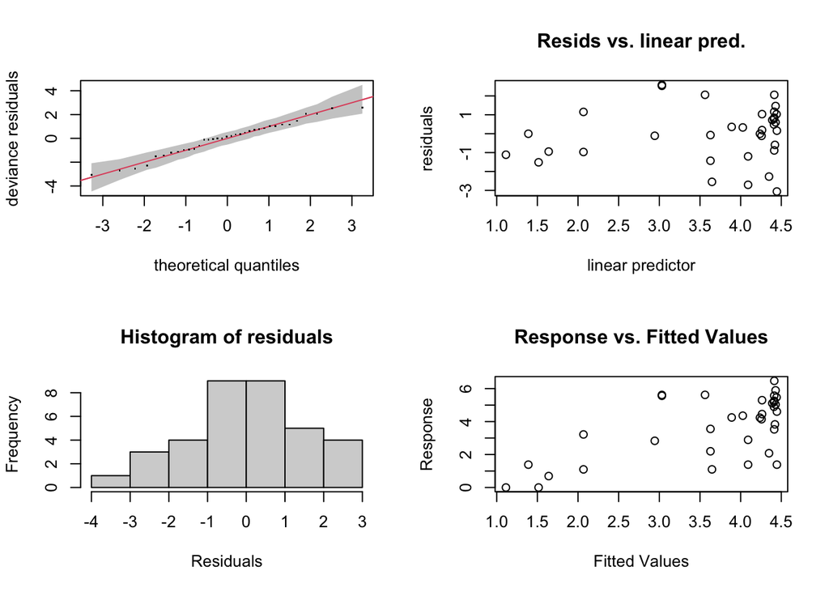

```
##
## Method: REML   Optimizer: outer newton
## full convergence after 15 iterations.
## Gradient range [-8.68914e-06,1.200216e-05]
## (score 66.16032 & scale 2.211979).
## eigenvalue range [-1.886487e-06,17.05735].
## Model rank =  46 / 46
##
## Basis dimension (k) checking results. Low p-value (k-index<1) may
## indicate that k is too low, especially if edf is close to k'.
##
##                                           k'      edf k-index p-value
## s(sst_scale)                        9.00e+00 2.78e-05    0.92   0.290
## s(norm_openness_scale)              9.00e+00 1.80e+00    0.92   0.320
## s(mean_total_boat_counts_1km_scale) 9.00e+00 7.33e-01    0.70   0.020 *
## s(mean_app_fishing_hours_scale)     9.00e+00 3.73e-05    0.82   0.085 .
## s(Urchins_scale)                    9.00e+00 4.01e-05    1.06   0.530
## ---
## Signif. codes:  0 '***' 0.001 '**' 0.01 '*' 0.05 '.' 0.1 ' ' 1
```

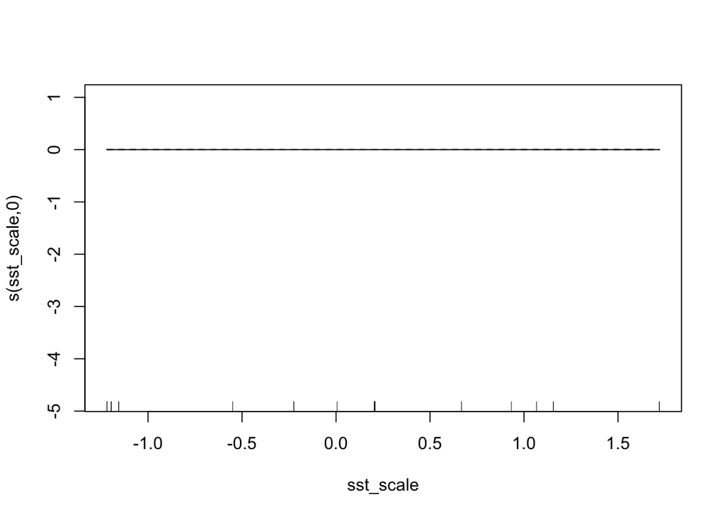

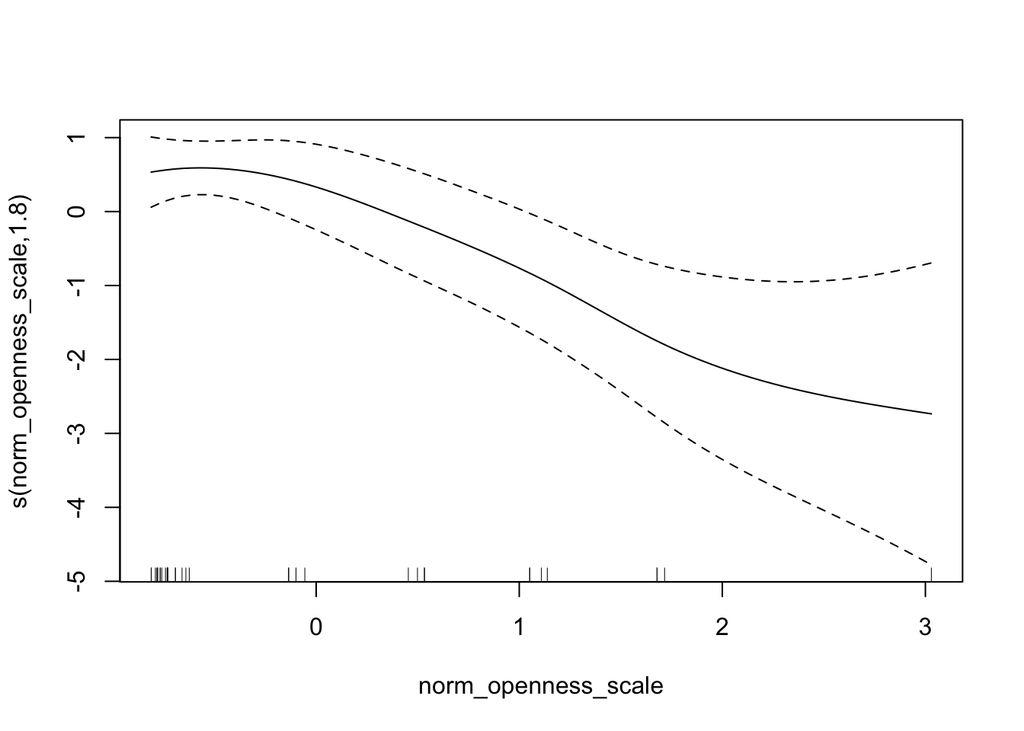

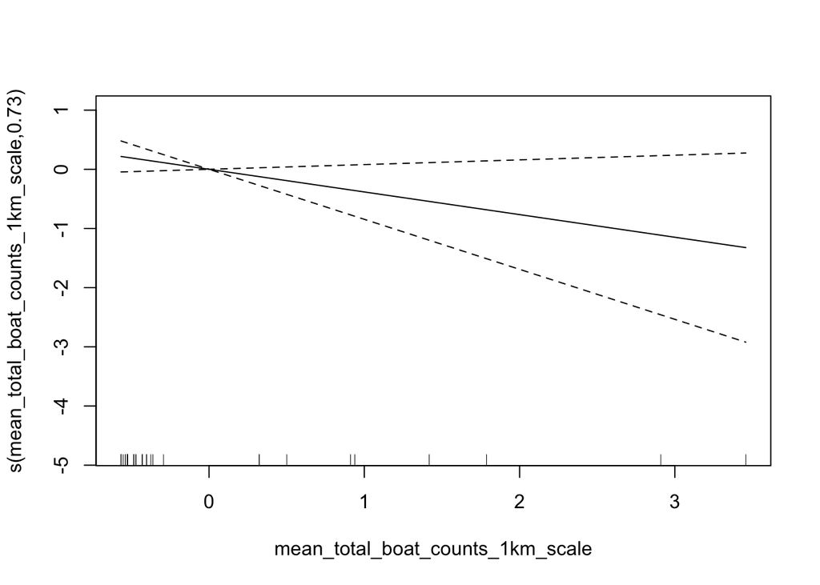

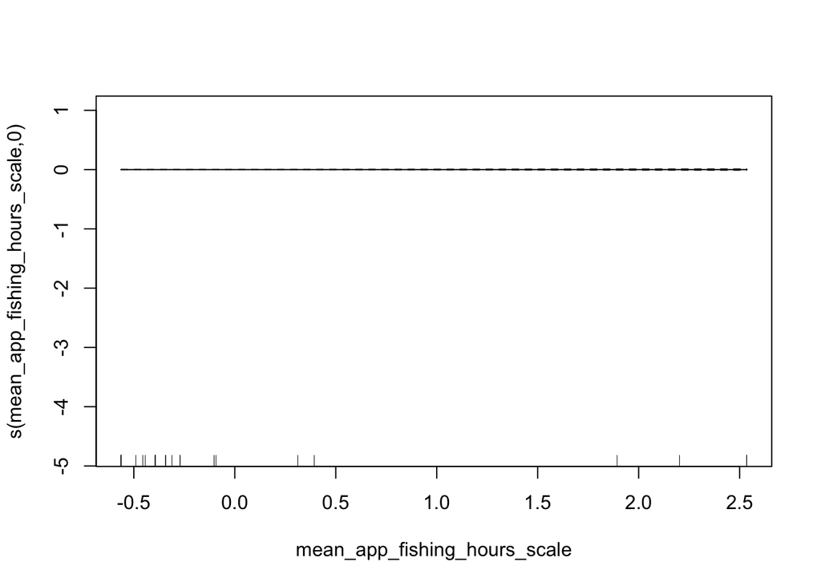

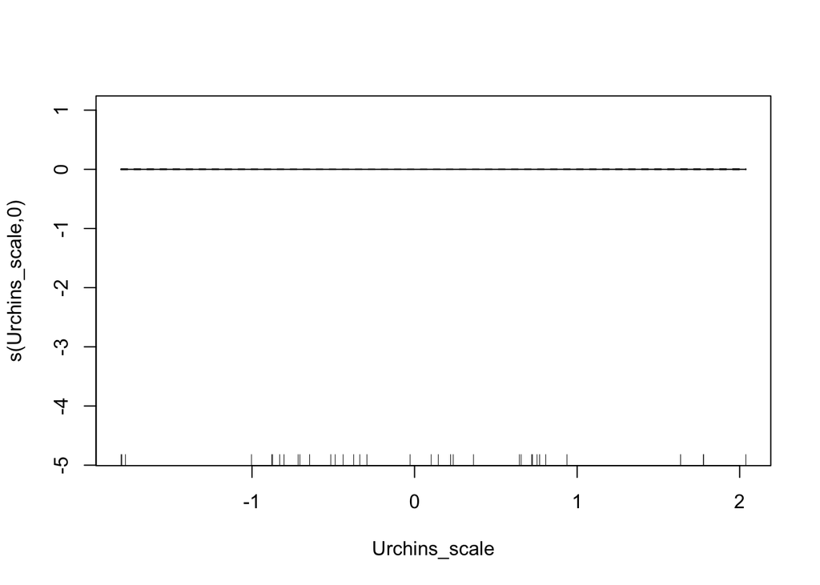

```
##
## Family: gaussian
## Link function: identity
##
## Formula:
## log(Turban_Snails + 1) ~ s(sst_scale) + s(norm_openness_scale) +
##     s(mean_total_boat_counts_1km_scale) + s(mean_app_fishing_hours_scale) +
##     s(Urchins_scale)
##
## Parametric coefficients:
##             Estimate Std. Error t value Pr(>|t|)
## (Intercept)   3.6633     0.2514   14.57 1.54e-15 ***
## ---
## Signif. codes:  0 '***' 0.001 '**' 0.01 '*' 0.05 '.' 0.1 ' ' 1
##
## Approximate significance of smooth terms:
##                                           edf Ref.df     F p-value
## s(sst_scale)                        2.784e-05      9 0.000  0.7158
## s(norm_openness_scale)              1.801e+00      9 1.523  0.1320
## s(mean_total_boat_counts_1km_scale) 7.327e-01      9 0.309  0.0595 .
## s(mean_app_fishing_hours_scale)     3.732e-05      9 0.000  0.4730
## s(Urchins_scale)                    4.005e-05      9 0.000  0.5982
## ---
## Signif. codes:  0 '***' 0.001 '**' 0.01 '*' 0.05 '.' 0.1 ' ' 1
##
## R-sq.(adj) =   0.36   Deviance explained = 40.8%
## -REML =  66.16  Scale est. = 2.212     n = 35
```

```
##
##  Shapiro-Wilk normality test
##
## data:  total_mod_snail_counts_1km_nb$residuals
## W = 0.9746, p-value = 0.581
```

##### Testing the residuals for autocorrelation

```
##
##  Moran I test under randomisation
##
## data:  residuals_total_mod_snail_counts_1km_nb
## weights: lw
## n reduced by no-neighbour observations
##
## Moran I statistic standard deviate = 0.95272, p-value = 0.1704
## alternative hypothesis: greater
## sample estimates:
## Moran I statistic       Expectation          Variance
##        0.25079486       -0.05882353        0.10561501
```

##### Testing the model for concurvity

```
## $worst
##                                             para s(sst_scale)
## para                                1.000000e+00 4.176841e-24
## s(sst_scale)                        4.182745e-24 1.000000e+00
## s(norm_openness_scale)              1.365135e-17 9.527043e-01
## s(mean_total_boat_counts_1km_scale) 8.105300e-18 8.466783e-01
## s(mean_app_fishing_hours_scale)     6.545436e-17 9.996134e-01
## s(Urchins_scale)                    5.729588e-19 8.167001e-01
##                                     s(norm_openness_scale)
## para                                          1.365142e-17
## s(sst_scale)                                  9.527043e-01
## s(norm_openness_scale)                        1.000000e+00
## s(mean_total_boat_counts_1km_scale)           9.705147e-01
## s(mean_app_fishing_hours_scale)               8.987165e-01
## s(Urchins_scale)                              7.238733e-01
##                                     s(mean_total_boat_counts_1km_scale)
## para                                                       8.105327e-18
## s(sst_scale)                                               8.466783e-01
## s(norm_openness_scale)                                     9.705147e-01
## s(mean_total_boat_counts_1km_scale)                        1.000000e+00
## s(mean_app_fishing_hours_scale)                            9.999935e-01
## s(Urchins_scale)                                           6.991012e-01
##                                     s(mean_app_fishing_hours_scale)
## para                                                   6.545414e-17
## s(sst_scale)                                           9.996134e-01
## s(norm_openness_scale)                                 8.987165e-01
## s(mean_total_boat_counts_1km_scale)                    9.999935e-01
## s(mean_app_fishing_hours_scale)                        1.000000e+00
## s(Urchins_scale)                                       9.203864e-01
##                                     s(Urchins_scale)
## para                                    5.729577e-19
## s(sst_scale)                            8.167001e-01
## s(norm_openness_scale)                  7.238733e-01
## s(mean_total_boat_counts_1km_scale)     6.991012e-01
## s(mean_app_fishing_hours_scale)         9.203864e-01
## s(Urchins_scale)                        1.000000e+00
##
## $observed
##                                             para s(sst_scale)
## para                                1.000000e+00 2.090289e-30
```

[output cut: 55 more lines]

```
## s(Urchins_scale)                                           1.577624e-01
##                                     s(mean_app_fishing_hours_scale)
## para                                                   5.634184e-21
## s(sst_scale)                                           4.095968e-01
## s(norm_openness_scale)                                 2.390114e-01
## s(mean_total_boat_counts_1km_scale)                    7.899466e-01
## s(mean_app_fishing_hours_scale)                        1.000000e+00
## s(Urchins_scale)                                       1.830437e-01
##                                     s(Urchins_scale)
## para                                    3.760244e-21
## s(sst_scale)                            4.697333e-01
## s(norm_openness_scale)                  3.820995e-01
## s(mean_total_boat_counts_1km_scale)     1.589990e-01
## s(mean_app_fishing_hours_scale)         5.140918e-01
## s(Urchins_scale)                        1.000000e+00
```

Some high concurvity so might need to eliminate certain variables.